# Exploratory Data Analysis

### Chi-squared for Heart Disease and Stroke

```r
chisq.test(HD$heart_disease,HD$stroke)
```

```
    Pearson's Chi-squared test with Yates' continuity correction

data:  HD$heart_disease and HD$stroke
X-squared = 66.267, df = 1, p-value = 3.937e-16
```

### Calculate Prevalence –see explanation in CONCLUSION

```r
PrevHDStroke<- (47/4254)*100
PrevHDStroke
```

```
[1] 1.104843
```

```r
PrevStrokeinHD<- (47/275)*100
PrevStrokeinHD
```

```
[1] 17.09091
```

### RESEARCH QUESTION 2: Do patients with heart disease also smoke?

According to the CDC, 14% (34 million) of US adults are smokers.How any patients with heart disease are former smokers and how many are current smokers? Ideally, as smoking is a risk factor, patients stop smoking after being diagnosed with heart disease. Let’s find out if patients with heart disease are also smokers..

```r
HD %>%
    count(heart_disease, smoking_status, sort = TRUE) %>%
  head(8)
```

```
  heart_disease  smoking_status    n
1            No    never smoked 1662
2            No         Unknown  815
3            No formerly smoked  783
4            No          smokes  719
5           Yes    never smoked   90
6           Yes formerly smoked   77
7           Yes          smokes   61
8           Yes         Unknown   47
```

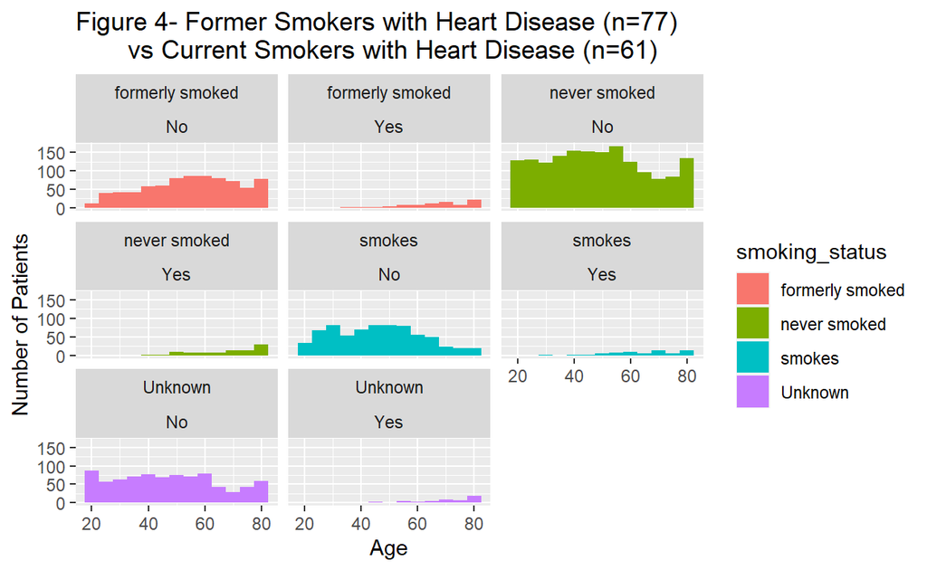

```r
ggplot(HD, aes(x=age, fill=smoking_status))+
  geom_histogram(binwidth = 5)+
  facet_wrap(vars(smoking_status,heart_disease))+
  labs(x="Age", y="Number of Patients", title =
  "Figure 4- Former Smokers with Heart Disease (n=77)
       vs Current Smokers with Heart Disease (n=61)")
```

EXPLANATION: Used geom_histogram facet_wrap to show distribution of growing age between 8 groups (heart disease and different smoking status groups)

### Chi-squared test for Heart Disease and Smoking Status

```r
chisq.test(HD$heart_disease,HD$smoking_status)
```

```
    Pearson's Chi-squared test

data:  HD$heart_disease and HD$smoking_status
X-squared = 17.75, df = 3, p-value = 0.0004954
```

OBSERVATION: The data set showed that there are 61 patients who have heart disease and are also smokers. The data can not identify if the 77 former smokers quit smoking before or after being diagnosed with heart disease.

### Calculate Prevalence –See explanation in CONCLUSION

```r
PrevSmokerHD<- (61/275)*100
PrevSmokerHD
```

```
[1] 22.18182
```

```r
NumericHD <- subset(HD, select= c("age","avg_glucose_level","bmi"))
```

### RESEARCH QUESTION 3. Are older people more likely to have obesity or have diabetes? For this question, we will use the CDC definition of obesity as BMI>or=30 and diabetes as average glucose levels > 200.

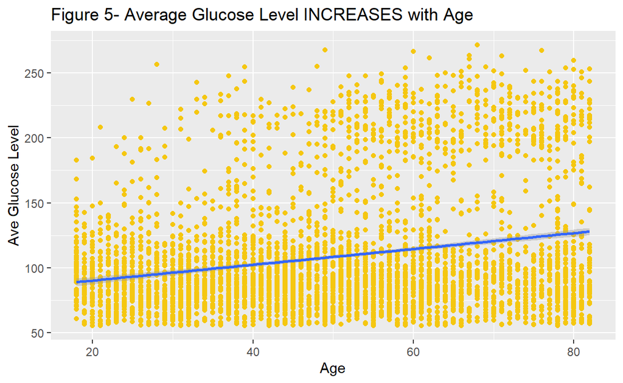

```r
ggplot(HD, aes(x = age, y = avg_glucose_level)) +
    geom_point(color=7) +
    geom_smooth(method = "lm") +
    labs(x="Age", y="Ave Glucose Level", title = "Figure 5- Average Glucose Level INCREASES with Age")
```

EXPLANATION: Used geom_point to show scatter plot distribution of growing age and glucose level

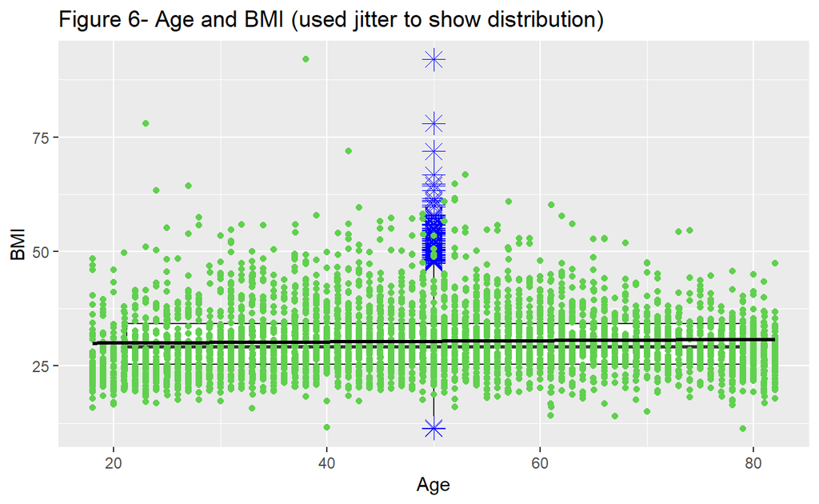

```r
ggplot(HD, aes(x = age, y = bmi, color=bmi)) +
    geom_boxplot(outlier.colour="blue", outlier.shape=8,
                outlier.size=4) +
    geom_jitter(width = 0.01,colour = 3)+
    geom_smooth(method = "lm",colour = 1) +
    labs(x="Age", y="BMI", title = "Figure 6- Age and BMI (used jitter to show distribution)")
```

EXPLANATION: Used geom_boxplot to show median, quartiles and used jitter to show distribution.

```r
HD.aov <- aov(age ~ bmi + avg_glucose_level, data = HD)
# Summary of the analysis
summary(HD.aov)
```

```
                    Df  Sum Sq Mean Sq F value Pr(>F)
bmi                  1    1373    1373   4.569 0.0326 *
avg_glucose_level    1   64603   64603 215.019 <2e-16 ***
Residuals         4070 1222853     300
---
Signif. codes:  0 '***' 0.001 '**' 0.01 '*' 0.05 '.' 0.1 ' ' 1
181 observations deleted due to missingness
```

## REFLECTION

This is my first time dabbling in R and I found it very interesting to learn. With my healthcare background, my inclination was to find a health-related data set. The Stroke Prediction data set from kaggle is relatively clean and only needed some tidying such as the focus on only adult patients (filtering out children). Although it is a Stroke Prediction data, I found researching on prevalence of heart disease, the leading cause of death in US, more interesting.

The biggest challenge I had was building a machine learning model at Homework 6. To do this, I first needed to balance the data set, which is common when using healthcare data sets. I was looking to build a classification model and apply machine learning in R. I started this process when I split the data (train and test) then balanced the data set. After my Random Forest Sampling in homework 6, I got stuck with the Confusion Matrix and could not finish my predictive model. This will be my next step as I plan to learn more on neural networks.

## CONCLUSION:

Based on statistical analysis, the association of hypertension and stroke with heart disease is significant.

For Research Question 1A: The prevalence of heart disease and hypertension in total patients is 1.50%. The prevalence of hypertension in patients WITH heart disease is 23.27%.

For Research Question 1B: The prevalence of heart disease AND stroke in total patients is 1.10%. The prevalence of stroke in patients WITH heart disease is 17.09%.

Smoking status is associated with heart disease and the data indicates that 61 patients who have heart disease are current smokers. This is a 22.18% prevalence rate of smokers in patients with heart disease.

Another conclusion from this data set is that increase in glucose levels is positively associated with aging. Older people are more likely to have higher glucose levels than younger patients. This data showed statistical significance in age and bmi but visually, the correlation is very minimal as evidenced by a near-zero slope. Although the data also indicates a median below 30, meaning most of the patients in this data are not obese, there is too many outliers to make a definite conclusion. More statistical analysis is recommended.

#### BIBLIOGRAPHY:

1. Fedesoriano. (2021, January 26). Stroke prediction dataset. Kaggle. Retrieved January 17, 2022, from https://www.kaggle.com/fedesoriano/stroke-prediction-dataset.
2. Wickham, H., & Grolemund, G. (2016). R for data science: Visualize, model, transform, tidy, and import data. OReilly Media.
3. R Core Team (2017). R: A language and environment for statistical computing. R Foundation for Statistical Computing, Vienna, Austria. URL https://www.R-project.org/.
4. Centers for Disease Control and Prevention. (2022, January 13). FASTSTATS - leading causes of death. Centers for Disease Control and Prevention. Retrieved January 16, 2022, from https://www.cdc.gov/nchs/fastats/leading-causes-of-death.htm
5. Centers for Disease Control and Prevention. (2021, September 27). Adult obesity prevalence maps. Centers for Disease Control and Prevention. Retrieved January 18, 2022, from https://www.cdc.gov/obesity/data/prevalence-maps.html#age
6. Centers for Disease Control and Prevention. (2020, December 10). Current cigarette smoking among adults in the United States. Centers for Disease Control and Prevention. Retrieved January 23, 2022, from https://www.cdc.gov/tobacco/data_statistics/fact_sheets/adult_data/cig_smoking/index.htm